```python
import pandas as pd
import matplotlib.pyplot as plt
import statsmodels.api as sm
from sklearn.linear_model import LinearRegression
import numpy as np
```

```python
df = pd.read_csv("student_exam_scores.csv")
```

# Analysis of Exam Scores

This report explores a dataset of student exam scores with the goal of analyzing key variables and identifying potential relationships between them. The analysis focuses on uncovering patterns in performance and examining how different factors may influence outcomes.

### Here we have an initial overview of the data

```python
# Basic info
print(df.info())

# Summary stats
print(df.describe())

# Preview
print(df.head())
```

```
<class 'pandas.core.frame.DataFrame'>
RangeIndex: 200 entries, 0 to 199
Data columns (total 6 columns):
 #   Column              Non-Null Count  Dtype
---  ------              --------------  -----
 0   student_id          200 non-null    object
 1   hours_studied       200 non-null    float64
 2   sleep_hours         200 non-null    float64
 3   attendance_percent  200 non-null    float64
 4   previous_scores     200 non-null    int64
 5   exam_score          200 non-null    float64
dtypes: float64(4), int64(1), object(1)
memory usage: 9.5+ KB
None
       hours_studied  sleep_hours  attendance_percent  previous_scores  \
count     200.000000   200.000000          200.000000       200.000000
mean        6.325500     6.622000           74.830000        66.800000
std         3.227317     1.497138           14.249905        15.663869
min         1.000000     4.000000           50.300000        40.000000
25%         3.500000     5.300000           62.200000        54.000000
50%         6.150000     6.700000           75.250000        67.500000
75%         9.000000     8.025000           87.425000        80.000000
max        12.000000     9.000000          100.000000        95.000000

       exam_score
count  200.000000
mean    33.955000
std      6.789548
min     17.100000
25%     29.500000
50%     34.050000
75%     38.750000
max     51.300000
  student_id  hours_studied  sleep_hours  attendance_percent  previous_scores  \
0       S001            8.0          8.8                72.1               45
1       S002            1.3          8.6                60.7               55
2       S003            4.0          8.2                73.7               86
3       S004            3.5          4.8                95.1               66
4       S005            9.1          6.4                89.8               71

   exam_score
0        30.2
1        25.0
2        35.8
3        34.0
4        40.3
```

## We look at the variables individually

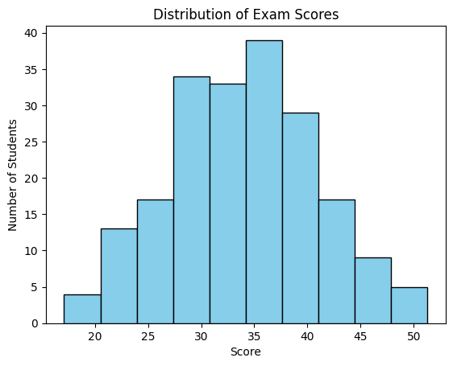

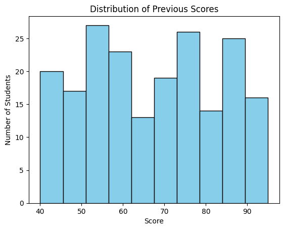

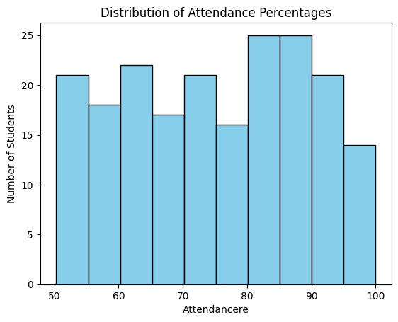

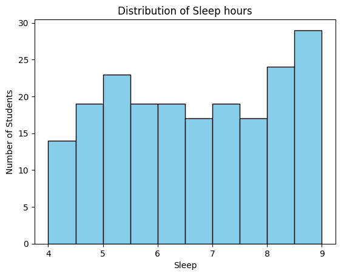

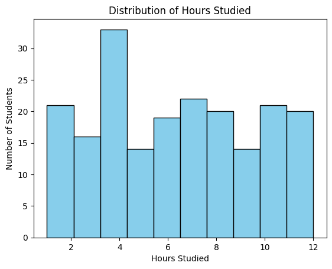

```python
# Plot histogram of a numeric column
df["exam_score"].plot(kind="hist", bins=10, color="skyblue", edgecolor="black", title="Distribution of Exam Scores")

# Add labels
plt.xlabel("Score")
plt.ylabel("Number of Students")

# Show the plot
plt.show()

# Plot histogram of a numeric column
df["previous_scores"].plot(kind="hist", bins=10, color="skyblue", edgecolor="black", title="Distribution of Previous Scores")

# Add labels
plt.xlabel("Score")
plt.ylabel("Number of Students")

# Show the plot
plt.show()


# Plot histogram of a numeric column
df["attendance_percent"].plot(kind="hist", bins=10, color="skyblue", edgecolor="black", title="Distribution of Attendance Percentages")

# Add labels
plt.xlabel("Attendancere")
plt.ylabel("Number of Students")

# Show the plot
plt.show()


# Plot histogram of a numeric column
df["sleep_hours"].plot(kind="hist", bins=10, color="skyblue", edgecolor="black", title="Distribution of Sleep hours")

# Add labels
plt.xlabel("Sleep")
plt.ylabel("Number of Students")

# Show the plot
plt.show()


# Plot histogram of a numeric column
df["hours_studied"].plot(kind="hist", bins=10, color="skyblue", edgecolor="black", title="Distribution of Hours Studied")

# Add labels
plt.xlabel("Hours Studied")
plt.ylabel("Number of Students")

# Show the plot
plt.show()
```

By visual inspection it appears as if exam scores follow a normal distribution, while none of the other variables appear to follow any common distributions.

### Boxplots to asses possible skewness or outliers

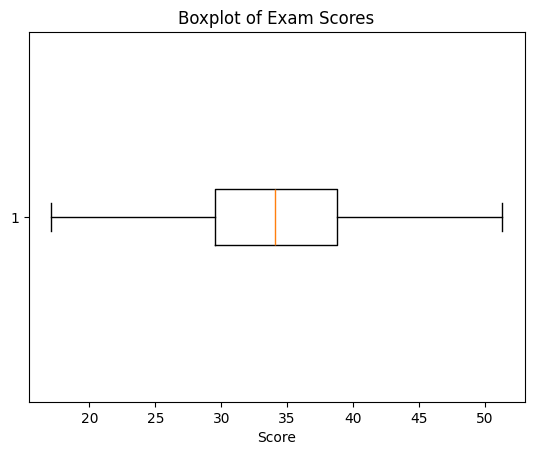

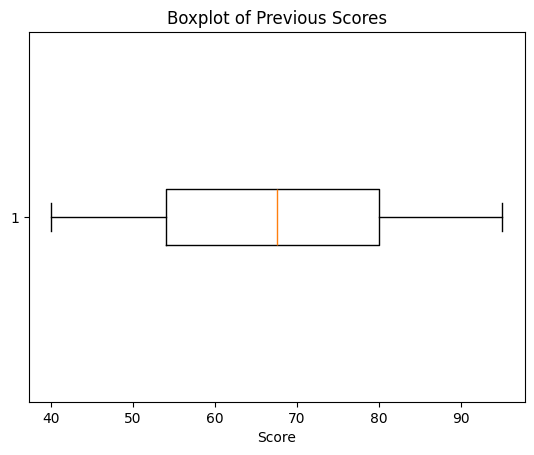

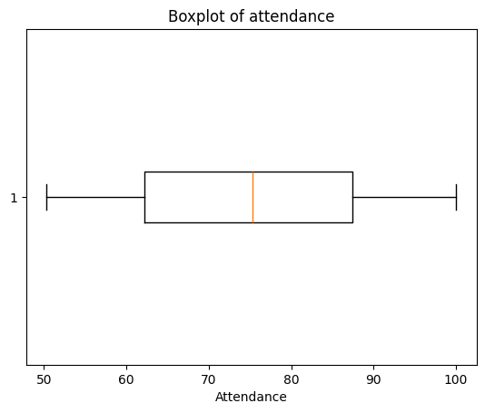

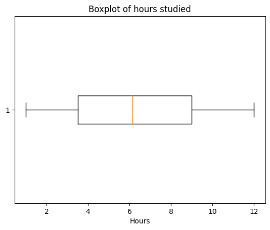

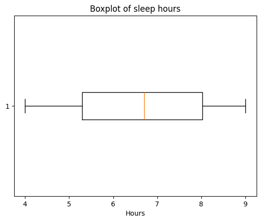

```python
# Boxplot exam scores
plt.boxplot(df['exam_score'], vert=False)
plt.title("Boxplot of Exam Scores")
plt.xlabel("Score")
plt.show()

# Boxplot previous scores
plt.boxplot(df['previous_scores'], vert=False)
plt.title("Boxplot of Previous Scores")
plt.xlabel("Score")
plt.show()

# Boxplot attendance
plt.boxplot(df['attendance_percent'], vert=False)
plt.title("Boxplot of attendance")
plt.xlabel("Attendance")
plt.show()

# Boxplot hours studied
plt.boxplot(df['hours_studied'], vert=False)
plt.title("Boxplot of hours studied")
plt.xlabel("Hours")
plt.show()

# Boxplot hours slept
plt.boxplot(df['sleep_hours'], vert=False)
plt.title("Boxplot of sleep hours")
plt.xlabel("Hours")
plt.show()
```

## We will now plot Exam Score against various variables

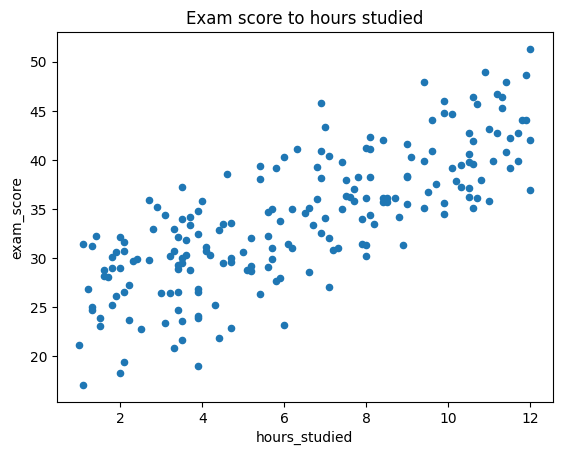

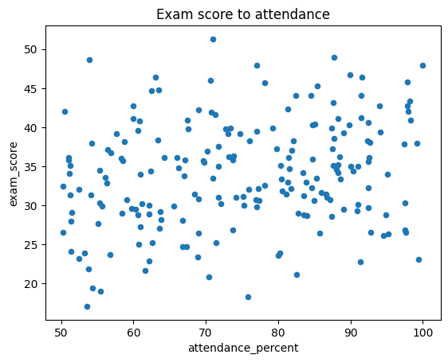

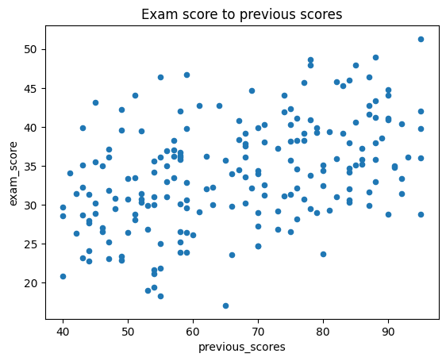

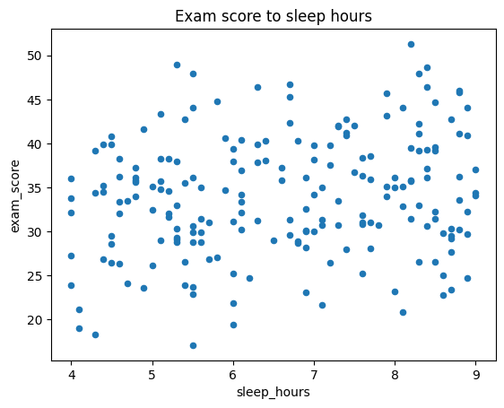

```python
df.plot(x = "hours_studied", y = "exam_score", kind = "scatter", title="Exam score to hours studied")
plt.show()
df.plot(x = "attendance_percent", y = "exam_score", kind = "scatter", title="Exam score to attendance")
plt.show()
df.plot(x = "previous_scores", y = "exam_score", kind = "scatter", title="Exam score to previous scores")
plt.show()
df.plot(x = "sleep_hours", y = "exam_score", kind = "scatter", title="Exam score to sleep hours")
plt.show()
```

By visual inspection, hours studied appears to have a strong positive linear correlation with exam scores, while the other variables show weaker or negligible correlations.

### Comparing average exam scores by hours studied

```python
grouped = df.groupby('hours_studied')['exam_score'].describe()
print(grouped)
```

```
               count       mean        std   min     25%    50%     75%   max
hours_studied
1.0              1.0  21.200000        NaN  21.2  21.200  21.20  21.200  21.2
1.1              2.0  24.250000  10.111627  17.1  20.675  24.25  27.825  31.4
1.2              1.0  26.800000        NaN  26.8  26.800  26.80  26.800  26.8
1.3              3.0  26.966667   3.669242  24.7  24.850  25.00  28.100  31.2
1.4              1.0  32.200000        NaN  32.2  32.200  32.20  32.200  32.2
...              ...        ...        ...   ...     ...    ...     ...   ...
11.5             2.0  40.700000   2.121320  39.2  39.950  40.70  41.450  42.2
11.7             2.0  41.300000   1.979899  39.9  40.600  41.30  42.000  42.7
11.8             1.0  44.100000        NaN  44.1  44.100  44.10  44.100  44.1
11.9             2.0  46.350000   3.181981  44.1  45.225  46.35  47.475  48.6
12.0             3.0  43.400000   7.301370  36.9  39.450  42.00  46.650  51.3

[96 rows x 8 columns]
```

This clear increase in average exam score as hours studied increases further reinforces the hypothesis that there exists a positive correlation between these two variables.

# Conclusion of EDA

## Regression Analysis

This section investigates whether a regression model can be used to predict exam scores.

```python
X = df["hours_studied"]
y = df["exam_score"]

X = sm.add_constant(X)  # add intercept
model = sm.OLS(y, X).fit()
print(model.summary())
```

```
                            OLS Regression Results
==============================================================================
Dep. Variable:             exam_score   R-squared:                       0.603
Model:                            OLS   Adj. R-squared:                  0.601
Method:                 Least Squares   F-statistic:                     301.2
Date:                Wed, 10 Sep 2025   Prob (F-statistic):           1.27e-41
Time:                        13:44:37   Log-Likelihood:                -573.90
No. Observations:                 200   AIC:                             1152.
Df Residuals:                     198   BIC:                             1158.
Df Model:                           1
Covariance Type:            nonrobust
=================================================================================
                    coef    std err          t      P>|t|      [0.025      0.975]
---------------------------------------------------------------------------------
const            23.6184      0.668     35.340      0.000      22.301      24.936
hours_studied     1.6341      0.094     17.354      0.000       1.448       1.820
==============================================================================
Omnibus:                        2.746   Durbin-Watson:                   2.104
Prob(Omnibus):                  0.253   Jarque-Bera (JB):                1.999
Skew:                          -0.044   Prob(JB):                        0.368
Kurtosis:                       2.518   Cond. No.                         15.9
==============================================================================

Notes:
[1] Standard Errors assume that the covariance matrix of the errors is correctly specified.
```

The R-squared value of 0.603 indicates that approximately 60.3% of the variation in exam scores can be explained by hours studied, suggesting a moderately strong relationship. To test whether hours studied is a statistically significant predictor at the 5% significance level, we compare the calculated t-value of 17.35 with the critical value of 1.97. Since 17.35 > 1.97, we reject the null hypothesis and conclude that hours studied is a useful predictor of exam score.

Therefore we will continue to determine a regression equation to predict exam score using hours studied.

### Finding the equation

```python
X = df[["hours_studied"]]   # 2D array
y = df["exam_score"].values

lr = LinearRegression()
lr.fit(X, y)

b0 = lr.intercept_
b1 = lr.coef_[0]

print(f"Regression equation: exam_score = {b0:.4f} + {b1:.4f} * hours_studied")
```

```
Regression equation: exam_score = 23.6184 + 1.6341 * hours_studied
```

## Conlcusion

The regression equation developed in this analysis demonstrates that hours studied is a statistically significant predictor of exam scores. With an R-squared value of 0.603, the model explains just over 60% of the variation in exam performance, suggesting that study time plays an important role in determining outcomes. While this equation can be used to predict exam scores with reasonable accuracy, it does not capture all the factors that influence performance. Other variables such as prior knowledge, study methods, and exam conditions may also contribute to exam results. Nonetheless, the analysis confirms that increased study hours are strongly associated with higher exam scores, and the regression model provides a useful tool for making predictions within the scope of the data.